# Lab-6

eagbozo@urfu.ru

1 April 2020

## Plotting Maps (combining GGPLOT)

Load airports data from the Open Flights website Rename the columns/variables Preview the dataset

```r
airports <- read.csv("https://raw.githubusercontent.com/jpatokal/openflights/master/data/airports.dat", header = FALSE)
colnames(airports) <- c("ID", "name", "city", "country", "IATA_FAA", "ICAO", "lat", "lon", "altitude", "timezone", "DST","Continent","extra1","extra2")

head(airports)
```

```
##   ID                                        name         city          country
## 1  1                              Goroka Airport       Goroka Papua New Guinea
## 2  2                              Madang Airport       Madang Papua New Guinea
## 3  3                Mount Hagen Kagamuga Airport  Mount Hagen Papua New Guinea
## 4  4                              Nadzab Airport       Nadzab Papua New Guinea
## 5  5 Port Moresby Jacksons International Airport Port Moresby Papua New Guinea
## 6  6                 Wewak International Airport        Wewak Papua New Guinea
##   IATA_FAA ICAO       lat     lon altitude timezone DST            Continent
## 1      GKA AYGA -6.081690 145.392     5282       10   U Pacific/Port_Moresby
## 2      MAG AYMD -5.207080 145.789       20       10   U Pacific/Port_Moresby
## 3      HGU AYMH -5.826790 144.296     5388       10   U Pacific/Port_Moresby
## 4      LAE AYNZ -6.569803 146.726      239       10   U Pacific/Port_Moresby
## 5      POM AYPY -9.443380 147.220      146       10   U Pacific/Port_Moresby
## 6      WWK AYWK -3.583830 143.669       19       10   U Pacific/Port_Moresby
##    extra1      extra2
## 1 airport OurAirports
## 2 airport OurAirports
## 3 airport OurAirports
## 4 airport OurAirports
## 5 airport OurAirports
## 6 airport OurAirports
```

Load the rworldmap library Plot our airport data unto the map (first plot the map and plot the points after)

```r
library(rworldmap)
```

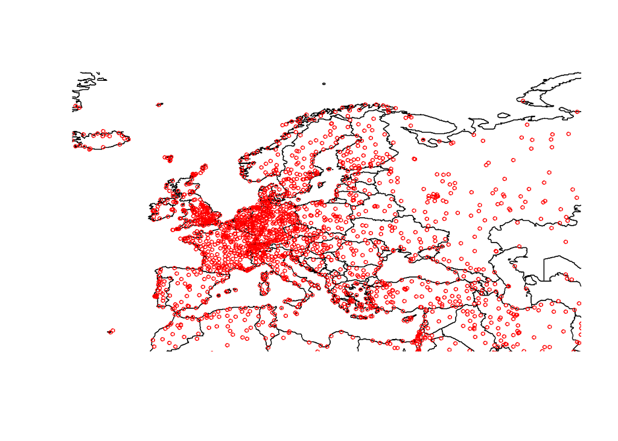

```r
newmap <- getMap(resolution = "low")

plot(newmap, xlim = c(-20, 59), ylim = c(35, 71), asp = 1)
points(airports$lon, airports$lat, col = "red", cex = .6)
```

Now let’s load the airport routes Rename the columns/variables Preview the dataset

```r
routes = read.csv("https://raw.githubusercontent.com/jpatokal/openflights/master/data/routes.dat", header = F)
colnames(routes) <- c("airline", "airlineID", "sourceAirport", "sourceAirportID", "destinationAirport", "destinationAirportID", "codeshare", "stops", "equipment")
head(routes)
```

```
##   airline airlineID sourceAirport sourceAirportID destinationAirport
## 1      2B       410           AER            2965                KZN
## 2      2B       410           ASF            2966                KZN
## 3      2B       410           ASF            2966                MRV
## 4      2B       410           CEK            2968                KZN
## 5      2B       410           CEK            2968                OVB
## 6      2B       410           DME            4029                KZN
##   destinationAirportID codeshare stops equipment
## 1                 2990               0       CR2
## 2                 2990               0       CR2
## 3                 2962               0       CR2
## 4                 2990               0       CR2
## 5                 4078               0       CR2
## 6                 2990               0       CR2
```

Load the plyr library, sum the number of departures and arrivals from the *routes* data frame by their source/destination airport ID. Rename these and column names as *flights* Join the new datasets (i.e. departures and arrivals) into the airports data frame (create two separate dataframes, one for arrivals and one for departures)

```r
library(plyr)
departures <- ddply(routes, .(sourceAirportID), "nrow")
names(departures)[2] <- "flights"

arrivals <- ddply(routes, .(destinationAirportID), "nrow")
names(arrivals)[2] <- "flights"

airportDest <- merge(airports, departures, by.x = "ID", by.y = "sourceAirportID")
airportAriv <- merge(airports, arrivals, by.x = "ID", by.y = "destinationAirportID")
```

#### ggplot2 and maps

```r
library(maps)
library(ggplot2)
our_world <- map_data("world")
```

Create a data frame from the *our_world* where the region is *Russia*

```r
Russia <- subset(our_world, our_world$region=="Russia")
head(Russia)
```

```
##           long      lat group order region subregion
## 75734 146.0456 43.40932  1242 75734 Russia         1
## 75735 146.0323 43.40713  1242 75735 Russia         1
## 75736 146.0280 43.42036  1242 75736 Russia         1
## 75737 146.0489 43.43359  1242 75737 Russia         1
## 75738 146.0886 43.44902  1242 75738 Russia         1
## 75739 146.1008 43.44019  1242 75739 Russia         1
```

Let’s create a blank slate we will use later on This layer will be added to any map later on so that we will clear all unecessary background objects

```r
blank_slate <-
  theme(panel.grid.major = element_blank(), panel.grid.minor = element_blank(),
        panel.background = element_rect(fill = 'white', colour = 'white'),
        axis.line = element_line(colour = "white"), legend.position="none",
        axis.ticks=element_blank(), axis.text.x=element_blank(),
        axis.text.y=element_blank())
```

Create a foundation layer upon which we will plot our maps unto Note: the contents are empty

```r
my_base <- ggplot() + coord_fixed() +
  xlab("") + ylab("")
```

Add map to *our_world* plot to the foundation layer (*my_base*) Take note: **x=long** and **y=lat**

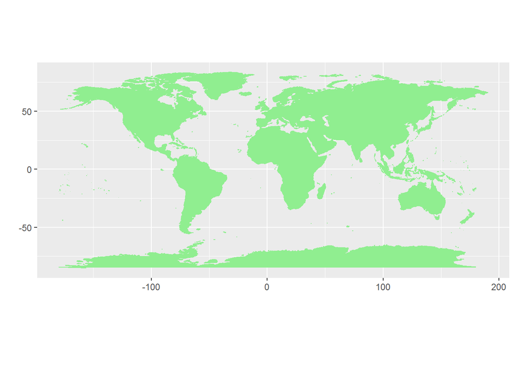

```r
world_plot <- my_base + geom_polygon(data=our_world, aes(x=long, y=lat, group=group),
                                     colour="light green", fill="light green")


world_plot
```

Let’s add data points from the *airportAriv* to *world_plot* map

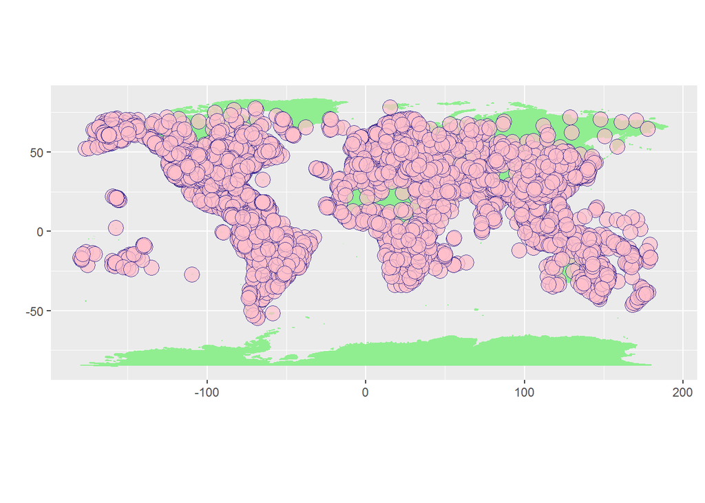

```r
  world_plot +
  geom_point(data=airportAriv,
             aes(x=lon, y=lat), colour="Navy Blue",
             fill="Pink",pch=21, size=5, alpha=I(0.7))
```

Now let’s make the data point locations correspond with their real values (*flights*)

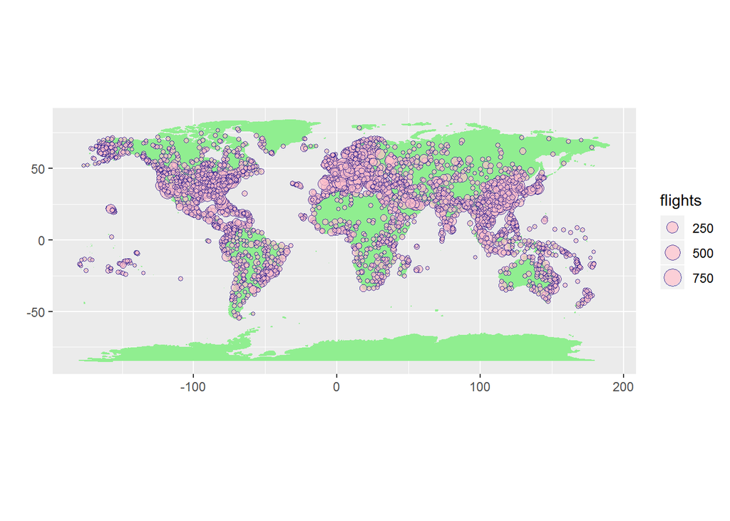

```r
  world_plot +
  geom_point(data=airportAriv,
             aes(x=lon, y=lat, size=flights), colour="Navy Blue",
             fill="Pink",pch=21, alpha=I(0.7))
```

Remember our Russia dataset, let’s plot all airports in Russia

```r
ru_basic <- my_base + geom_polygon(data=Russia, aes(x=long, y=lat, group=group),
                                           colour="light green", fill="light green")
```

create a data frame from the *airportAriv* data frame where the country is Russia and plot the arrival flights

```r
ru_air_ariv = subset(airportAriv, airportAriv$country=="Russia")

ru_maper <-
  ru_basic +
  geom_point(data=ru_air_ariv,
             aes(x=lon, y=lat, size=flights), colour="Blue",
             fill="Yellow",pch=21, alpha=I(0.7))
```

Let’s plot the previous map but this time we will include the blank layer (*blank_slate*) Also, using the geom_text() function, we will plot the cities as well.

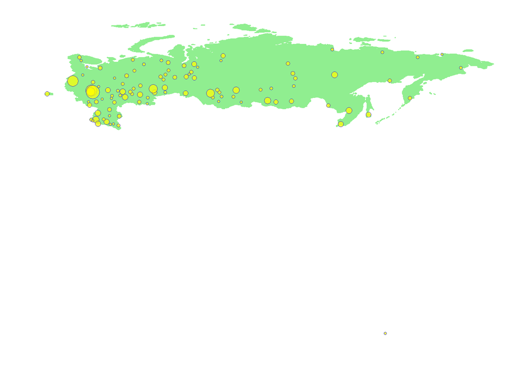

```r
ru_maper +blank_slate
```

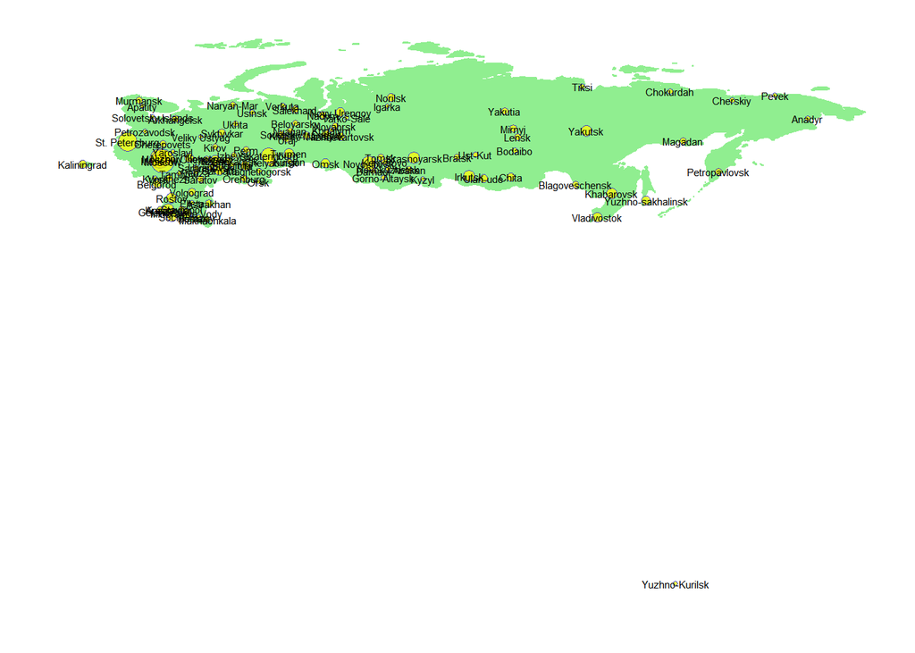

```r
ru_maper +blank_slate +
  geom_text(data=ru_air_ariv, aes(lon, lat, label = city), size=2)
```